# Probability Density Function

Victoria Nguyen

7/18/2021

## Introduction

Probability theory is fundamental in the study of statistics. This workbook will act as a guide to the functions built-in to R that help us look at **probability density functions**, or “PDFs”.

### Contents

1. What is a Probability Density Function?
2. Normal Distribution
3. Binomial Distribution

## What is a Probability Density Function?

The probability density function, or PDF, is the density of a continuous random variable, which takes on an infinite number of possible values. The PDF is used to find the relative likelihood for a random variable to take on a given value.

For discrete random variables, the *probability mass function* is P(X=x), which allows us to find the probability of X taking on any of its possible values.

For continuous random variables, the probability that X takes on a particular value x is 0, because we cannot find P(X=x) for a continuous random variable X - instead, we find the possibility that V falls in an *interval (a,b)*. In other words, **we use a probability density function to find P(a<X<b)**.

### Formula

The **probability density function (“PDF”)** of a continuous random variable with support $S$ is an integrable function $f(x)$ satisfying the following:

1. $f(x)$ is positive everywhere in the support $S$. In other words, $f(x) > 0$ for all $x$ in $S$.
2. The area under curve $f(x)$ in support $S$ = 1, meaning:
   $$\int_S f(x)dx= 1$$
3. If $f(x)$ is the PDF of $x$, then the probability that $x$ is in $A$, where $A$ is an interval, is found using the integral of $f(x)$ over said interval:
   $$P(X \in A) = \int_A f(x)dx$$

The PDF of a continuous random variable is different from the PMF of a discrete random variable as we look at integrals rather than summations.

R is capable of handling many of the mechanisms needed to deal with distributions. In this workbook, we will be looking at Normal and Binomial distributions, though that’s only a fraction of R’s capabilities.

The following 4 function prefixes are consistent for all distributions:

| Function | Purpose |
| --- | --- |
| `d_` | density |
| `p_` | cumulative distribution function |
| `q_` | quantile function (inverse of `p_`) |
| `r_` | random variates |

where `_` is the R name for the distribution, such as `norm` for normal distributions, or `binom` for binomial distributions.

## Normal Distribution

### When to Use

A continuous random variable $X$ follows a **normal distribution** when the PDF follows:

$$f(x)=\dfrac{1}{\sigma \sqrt{2\pi}} \text{exp}\left\{-\dfrac{1}{2} \left(\dfrac{x-\mu}{\sigma}\right)^2\right\}$$
for $-\infty<x<\infty$, $-\infty<x<\infty$, and $0<\sigma<\infty$, where $\mu$ is the mean of $X$ and $\sigma^2$ is the variance. $X \sim N( \mu,\sigma^2)$

Normal distributions are commonly used in statistics as many natural phenomena follow it. They have the following characteristics:

- symmetric, bell-shaped curve
- equal median and mean at the center of the distribution
- ~68% of data falling within 1 standard deviation of the center
- ~95% of data falling within 2 standard deviations of the center
- ~99.7% of data falling within 3 standard deviations of the center

### Functions

| Function | Purpose | Syntax | Example |
| --- | --- | --- | --- |
| `dnorm` | probability density function | `dnorm(x, mean, sd)` | `dnorm(0, 0, .6)` gives density (height of PDF) of the normal dist with mean=0 and sd=.6. |
| `pnorm` | cumulative distribution function | `pnorm(q, mean, sd)` | `pnorm(1.96, 0, 1)` gives area under the standard normal curve to left of 1.96 |
| `qnorm` | quantile function (inverse of `qnorm`) | `qnorm(p, mean, sd)` | `qnorm(0.975, 0, 1)` gives value at which the CDF of standard normal dist is .975 |
| `rnorm` | random variates from distribution | `rnorm(n, mean, sd)` | `rnorm(50, 2, .5)` gives 50 numbers from a normal with mean 2 and sd=.5 |

### Example

```r
#Using sample_n() from the dplyr package

set.seed(07212021)
ToothGrowth_data <- ToothGrowth
dplyr::sample_n(ToothGrowth_data, 20)
```

```
##     len supp dose
## 1  29.4   OJ  2.0
## 2   9.7   OJ  0.5
## 3  14.5   OJ  0.5
## 4  23.6   OJ  1.0
## 5  22.4   OJ  2.0
## 6  23.3   VC  2.0
## 7  16.5   OJ  0.5
## 8  17.6   OJ  0.5
## 9  16.5   VC  1.0
## 10 11.2   VC  0.5
## 11 15.2   VC  1.0
## 12  9.7   OJ  0.5
## 13  6.4   VC  0.5
## 14 13.6   VC  1.0
## 15 20.0   OJ  1.0
## 16  8.2   OJ  0.5
## 17 26.7   VC  2.0
## 18 14.5   OJ  1.0
## 19 23.3   OJ  1.0
## 20 11.2   VC  0.5
```

If you can recall, the **central limit theorem** says that we can assume a sampling distribution to be normal if it’s large enough (n>30). If the sample size is less than 30, or if you would like to be consistent, we can check for normality using histograms (normal plots), quantile-quantile plots, or significance tests.

#### Testing for Normality

**Plots**

We will be using the `ggpubr` library for our plots.

A *density plot* will help determine, visually, whether our distribution is bell-shaped.

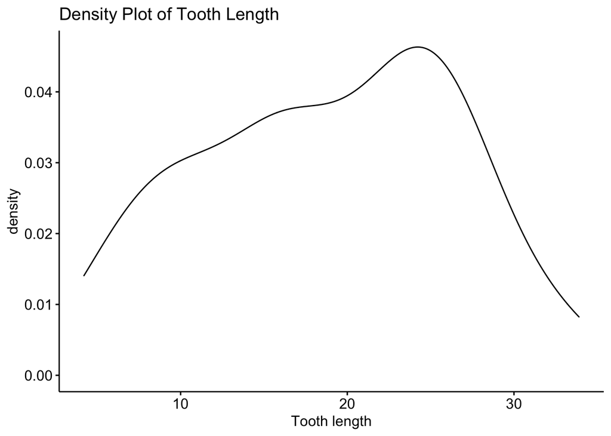

```r
library("ggpubr")
ggdensity(ToothGrowth_data$len,
          main = "Density Plot of Tooth Length",
          xlab = "Tooth length")
```

We can see that the density does not have a symmetric, bell-shaped curve.

We can also use a *quantile-quantile plot*, AKA a Q-Q plot, to see visually how close our distribution is to following the desired bell-shaped curve.

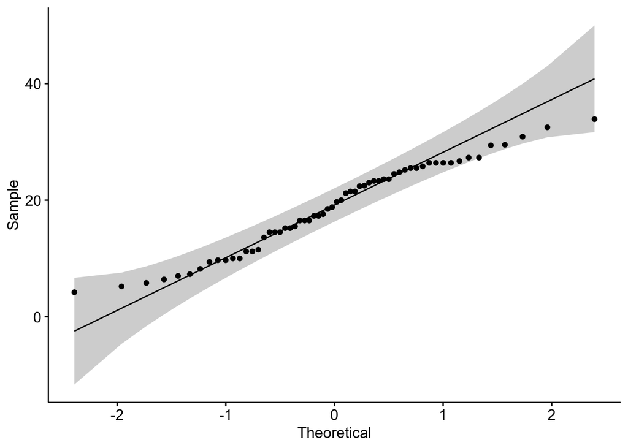

```r
library("ggpubr")
ggqqplot(ToothGrowth_data$len)
```

As you can see, though the curve wasn’t bell-shaped when we looked at the density plot, most data points fall along the diagonal reference line, so we can assume normality.

**Normality Test**

While it’s nice to do visual tests, it can be unreliable as we have to do qualitative assessment. Instead, we can use a *significance test* to see how our sample distribution compares to a true, normal distribution.

Here, we will use *Shapiro-Wilk’s*. It is based on the correlation between the data and their corresponding normal scores.

```r
shapiro.test(ToothGrowth_data$len)
```

```
##
##  Shapiro-Wilk normality test
##
## data:  ToothGrowth_data$len
## W = 0.96743, p-value = 0.1091
```

As long as the p-value is greater than 0.05, we can gather that the sample distribution’s data doesn’t fall too far from a normal distribution, meaning we can assume normality.

#### Using Functions

Now that we have assumed normality for our sample, let’s see what kind of information we can gather using R’s built-in functions.

We will need the range, mean, and standard deviation of the sample data.

```r
ToothGrowth_data_range  <- range(ToothGrowth_data$len)
ToothGrowth_data_mean   <- mean(ToothGrowth_data$len)
ToothGrowth_data_sd     <- sd(ToothGrowth_data$len)
```

We can then use `dnorm()` to find the value of the probability density function.

```r
tooth_dist <- dnorm(ToothGrowth_data_range, ToothGrowth_data_mean, ToothGrowth_data_sd )
tooth_dist
```

```
## [1] 0.008409535 0.007457625
```

```r
tooth_cdf <- pnorm(26,ToothGrowth_data_mean,ToothGrowth_data_sd )
tooth_cdf
```

```
## [1] 0.8262675
```

```r
qnorm(.85,ToothGrowth_data_mean,ToothGrowth_data_sd)
```

```
## [1] 26.74134
```

```r
#this means that 85% of values in the sample will lie below 26.74134.
```

Lastly, we can use `rnorm()` to pull a specified amount of normally distributed numbers from our distribution. Here, I’m pulling 5.

```r
rnorm(5, ToothGrowth_data_mean, ToothGrowth_data_sd )
```

```
## [1] 25.52751 -3.95718 16.99096 26.34856 19.67608
```

## Binomial Distribution

### When to Use

We use a **binomial distribution** under the following conditions:

- the number of observations, n, is fixed
- each observation is independent
- there are two possible outcomes per observation (typically “success” and “failure”)
- the probability of success for each observation is the same.

The most well-known application of the binomial distribution is in finding the probability of landing $x$ amount of heads in $n$ number of coin flips.

The probability that a random variable $X$ with binomial distribution B(n,p) is equal to the value k, where k = 0,…n , is given by:

$P(X=k)= \binom{n}{k}p^k (1-p)^{(n-k)}$ , where $\binom{n}{k} = \frac{n!}{k!(n-k)!}$

$p$ is the probability of success, $q$ is the probability of failure, $n$ is the number of trials.

### Functions

The functions for binomial distributions are similar to those we used for normal distributions.

| Function | Purpose | Syntax | Example |
| --- | --- | --- | --- |
| `dbinom` | probability density function | `dbinom(x, size, prob)` | `dbinom(3, 10, .5)` probability of having exactly 3 successes out of 10 .5 chance attempts |
| `pbinom` | cumulative distribution function | `pbinom(q, size, prob)` | `pbinom(3, 10, .5)` probability of 3 or less successes our of 10 .5 chance attempts |
| `qbinom` | quantile function (inverse of `pbinom`) | `qbinom(p, size, prob)` | `qbinom(3, 10, .5)` gives the pth quantile of the binomial distribution |
| `rbinom` | random variates from distribution | `rbinom(n, size, prob)` | `rbinom(3, 10, .5)` generates a vector of 3 binomial distributed random variables in 10 .5 chance trials |

### Example

Imagine we’re throwing dice 20 times. Assuming it’s fair, there is a $\frac{1}{6}$ chance of it landing on any given side. We’re interested in the dice landing on 1 or 2, making it a $\frac{1}{3}$ or approximately $.33$ probability of success.

Use `dbinom()` to find the probability that *exactly* 9 of the rolls will land on 1 or 2.

```r
dbinom(9, 20, .33)
```

```
## [1] 0.09520377
```

Now, use `pbinom()` to find the probability that there will be anywhere between 0 and 9 successes.

```r
pbinom(9, 20, .33)
```

```
## [1] 0.913422
```

What’s the .5 quantile of this distribution?

```r
qbinom(.5, 20, .33)
```

```
## [1] 7
```

Finally, generate a vector of 6 random variables in this distribution.

```r
rbinom(6, 20, .33)
```

```
## [1]  4 10  4  6  5 10
```

## Resources

Other Helpful Resources:

1. [Penn State: An explanation of Probability Density Functions](https://online.stat.psu.edu/stat414/lesson/14/14.1)
2. [R Cookbook: Probability](https://rc2e.com/probability)
3. [MarinStatsLectures(Youtube): Using R for Normal Distributions](https://www.youtube.com/watch?v=peEsXbdMY_4)
4. [Statistics How-To: Binomial Distributions](https://www.statisticshowto.com/probability-and-statistics/binomial-theorem/binomial-experiment/)